# Smurf Account Analysis

September 12, 2016

### Analysis Overview

The smurf analysis looks at each users’ (eg Amplitude_id) account (eg playerid) by account level to determine the status of an account. This was done to answer the following questions:

*What percent of Daily Active Accounts (DAA) are smurfs?*  
*For DAU, in the last 30 days how many active smurf accounts do they have?*

**Methodology**: Preliminary analysis determined that an account is tracked by the playerid. For each account a user has, the level and LTD minutes played were used to classify the account type. Accounts were classified into three groups: Sub-Smurf, Smurf, and Main.

- **Account Classification Conditions**:
  - **Sub-Smurf**: playerid’s level <= 3, the playerid is not the highest ranking playerid the user has, and the playerid is not the most played (in minutes) account the user has.
  - **Smurf**: playerid’s >= 3, the playerid is not the highest ranking playerid the user has, and the playerid is not the most played (in minutes) account the user has.
  - **Main**: the account is at the highest level rank a user has AND is the highest ranked account in terms of minutes played.
- **Data Issues**:
  - the `player_id` user property is available in `app_login` and `game_match_finish` from 4/3/2016 onwards.

For many older accounts we do not have the full minutes played counts amd we are likely assinging a small portion of highly engaged veteran users’ main account to a smurf. Many of these veterans have several level 30 accounts. However, this is not too problematic.

### DAU 30 Day Smurf Dist.

To create the distribution, each users’ accounts were counted, then users were grouped by their count of accounts.

Below is the distribution of 30 day active smurf accounts for DAU.

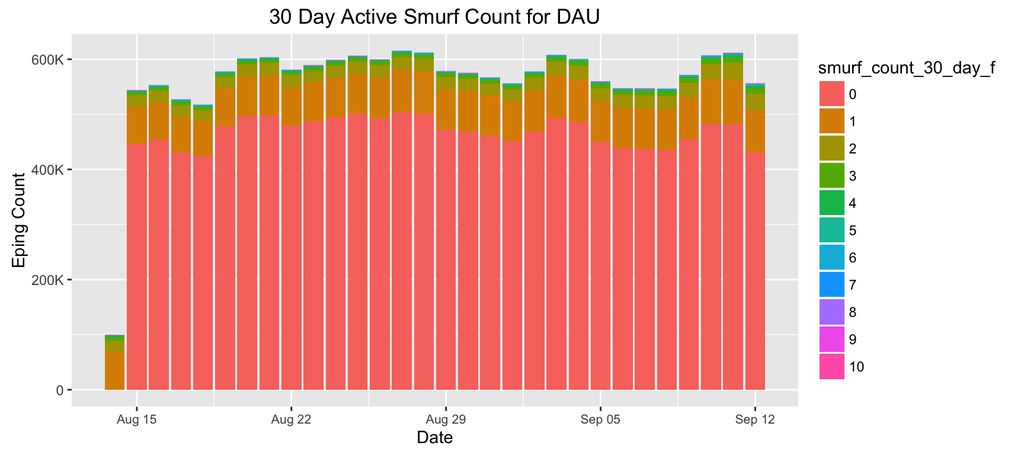

### DAA Classificaton

In the chart below, Daily Active Accounts (eg DAA) are grouped by their Smurf Status to create a distribution of accounts by status.

- Findings:
  - 22% of DAA are non-Main accounts
- On average:
  - 78% are Main accounts,
  - 16% are Smurfs, and
  - 6% are Sub-Smurfs.

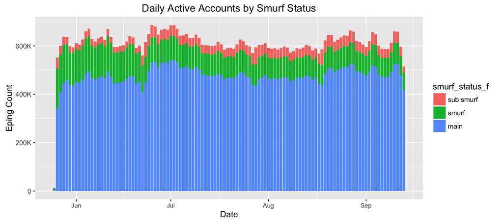